# Regression

## Linear regression

> It is based on optimization - minimization of sum of squares of residuals (differences between actual values and predicted values of the function). The algorithm tries to find the best possible fit (minimal sum of squares).

Simple linear regression is a model describing linear relationship between one numeric dependent variable and one independent variable. Multiple linear regression is used to describe a dependence on 2 or more independent variables.

At the beginning of our analysis, we can learn about the relation between two numeric variables using scatter plot or even calculating correlation coefficient.

```r
# Dataset contains info about speed and break distance of cars
str(cars)
```

```
## 'data.frame':    50 obs. of  2 variables:
##  $ speed: num  4 4 7 7 8 9 10 10 10 11 ...
##  $ dist : num  2 10 4 22 16 10 18 26 34 17 ...
```

```r
cor(cars$speed, cars$dist) # korelace mezi proměnnými
```

```
## [1] 0.8068949
```

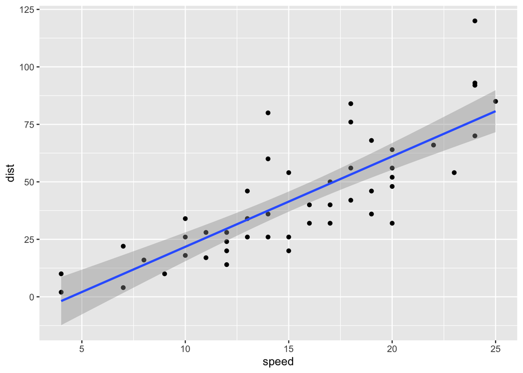

```r
ggplot(cars, aes(x = speed, y = dist)) +
  geom_point() +
  geom_smooth(method = "lm")
```

Absolute values of correlation coeffiecients close to 1 shows high correlation between variables (close to 0 means the opposite thus weak relationship between them).

```r
set.seed(123) # for reproducability of random sampling every time we run the code
sample_cars <- sample(c(TRUE, FALSE), nrow(cars), replace = TRUE, prob = c(0.8, 0.2)) # split the data to training (80 %) and test (20 %) set
train_cars <- cars[sample_cars, ]
test_cars <- cars[!sample_cars, ]

modelcar <- lm(dist~speed, data = train_cars)

# some model statistics
summary(modelcar)
```

```
##
## Call:
## lm(formula = dist ~ speed, data = train_cars)
##
## Residuals:
##     Min      1Q  Median      3Q     Max
## -30.079 -10.069  -4.093  11.961  41.961
##
## Coefficients:
##             Estimate Std. Error t value Pr(>|t|)
## (Intercept) -18.0562     8.5129  -2.121   0.0407 *
## speed         4.0068     0.5099   7.858 2.11e-09 ***
## ---
## Signif. codes:  0 '***' 0.001 '**' 0.01 '*' 0.05 '.' 0.1 ' ' 1
##
## Residual standard error: 16.73 on 37 degrees of freedom
## Multiple R-squared:  0.6253, Adjusted R-squared:  0.6152
## F-statistic: 61.75 on 1 and 37 DF,  p-value: 2.107e-09
```

The model gave us the intercept (the point where the function crosses y-axis when x = 0) and slope/coefficient. With a unit increase of speed we can expect an increase of 4.007 units of break distance.

Broom package lets us convert model objects to data frames for easier further programming. Let’s look at some of its functions.

```r
tidy(modelcar) # using package broom, we can tidy model to get coefficient-level elements
```

```
## # A tibble: 2 × 5
##   term        estimate std.error statistic       p.value
##   <chr>          <dbl>     <dbl>     <dbl>         <dbl>
## 1 (Intercept)   -18.1      8.51      -2.12 0.0407
## 2 speed           4.01     0.510      7.86 0.00000000211
```

```r
augment(modelcar) # to get observation-level of model elements
```

```
## # A tibble: 39 × 9
##    .rownames  dist speed .fitted .resid   .hat .sigma .cooksd .std.resid
##    <chr>     <dbl> <dbl>   <dbl>  <dbl>  <dbl>  <dbl>   <dbl>      <dbl>
##  1 1             2     4   -2.03   4.03 0.156    16.9 0.00634      0.262
##  2 2            10     4   -2.03  12.0  0.156    16.8 0.0565       0.782
##  3 3             4     7    9.99  -5.99 0.0983   16.9 0.00775     -0.377
##  4 6            10     9   18.0   -8.00 0.0692   16.9 0.00913     -0.496
##  5 7            18    10   22.0   -4.01 0.0574   17.0 0.00186     -0.247
##  6 9            34    10   22.0   12.0  0.0574   16.8 0.0166       0.738
##  7 10           17    11   26.0   -9.02 0.0474   16.9 0.00759     -0.552
##  8 12           14    12   30.0  -16.0  0.0394   16.7 0.0196      -0.977
##  9 13           20    12   30.0  -10.0  0.0394   16.9 0.00766     -0.611
## 10 14           24    12   30.0   -6.03 0.0394   16.9 0.00277     -0.367
## # ℹ 29 more rows
```

```r
glance(modelcar) # to get model-level elements (statistics)
```

```
## # A tibble: 1 × 12
##   r.squared adj.r.squared sigma statistic       p.value    df logLik   AIC   BIC
##       <dbl>         <dbl> <dbl>     <dbl>         <dbl> <dbl>  <dbl> <dbl> <dbl>
## 1     0.625         0.615  16.7      61.7 0.00000000211     1  -164.  334.  339.
## # ℹ 3 more variables: deviance <dbl>, df.residual <int>, nobs <int>
```

```r
modelcar %>%
  glance() %>%
  pull(r.squared) # dplyr function to extract a value from a tibble
```

```
## [1] 0.6252983
```

Now we can add predicted values and residuals to the training dataset to create a model plot.

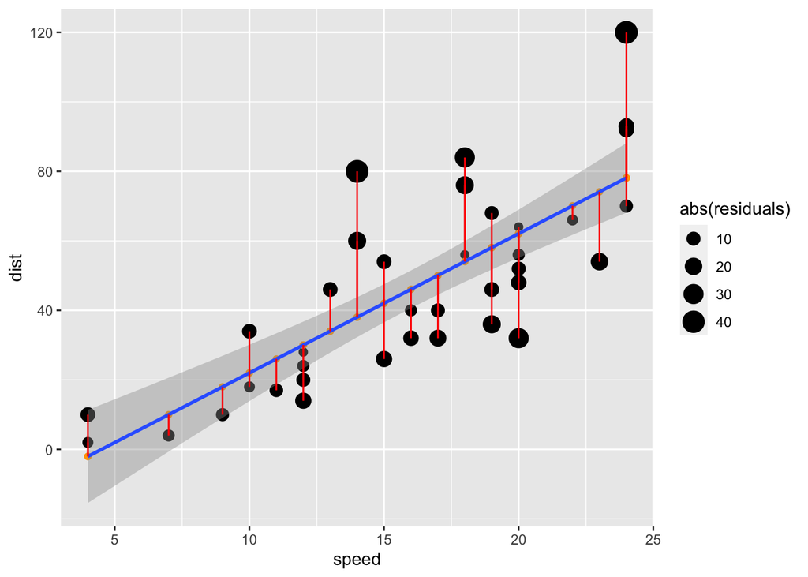

```r
plot_cars <- train_cars %>%
  mutate(estimate = predict(modelcar)) %>% # we could obtain the same using fitted(modelcar), or instead of running the model, we could use simple arithmetics (estimate = intercept + slope*explanatory variable)
  mutate(residuals = residuals(modelcar)) %>% # we could obtain the same by making a difference between original values and the fitted values
  ggplot(aes(speed, dist)) +
  geom_point(aes(size = abs(residuals))) +
  geom_point(aes(y = estimate), color = "orange") +
  geom_smooth(method = "lm") +
  geom_segment(aes(xend = speed, yend = estimate), color = "red")
plot_cars
```

```r
y_test <- data.frame(dist = test_cars[, 2])
x_test <- data.frame(speed = test_cars[, 1])
prediction <- data.frame(predict_y = predict(modelcar, x_test))
```

### Regression to the mean

This concepts is based on an idea that even though there is some noise in the data and the sample of a random variable seems to be extreme, in a long term perspective (next samplings) we can expect the values to be closer to that mean. Thus it is not recommended to draw final conclusions on just one sample but rather repeat the analysis multiple times to see the whole picture. You can learn more about this concept reading this [article](https://en.wikipedia.org/wiki/Regression_toward_the_mean).

Let’s explore data about height of fathers and their sons.

```r
heights_fs <- UsingR::father.son
str(heights_fs)
```

```
## 'data.frame':    1078 obs. of  2 variables:
##  $ fheight: num  65 63.3 65 65.8 61.1 ...
##  $ sheight: num  59.8 63.2 63.3 62.8 64.3 ...
```

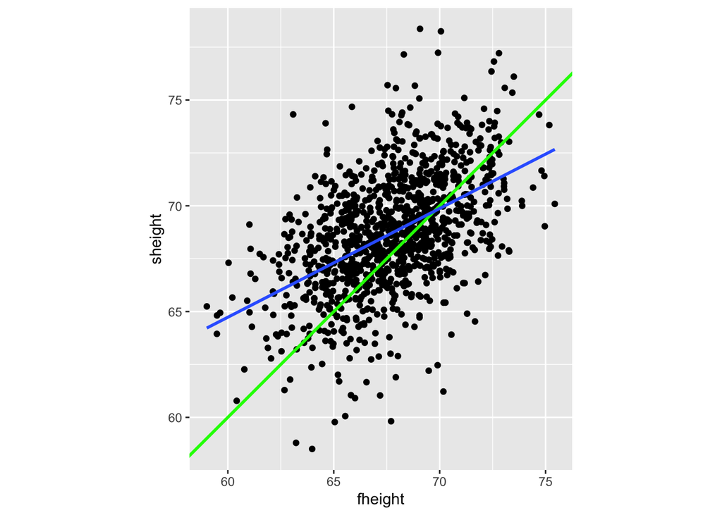

```r
ggplot(heights_fs, aes(fheight, sheight))+
  geom_point() +
  geom_abline(color = "green", linewidth = 1) +
  geom_smooth(method = "lm", se = FALSE) +
  coord_fixed() # to keep ticks intervals on x and y axis the same
```

Let’s run a linear regression model and predict some values.

```r
model_heights_fs <- lm(sheight ~ fheight, data = heights_fs)
model_heights_fs
```

```
##
## Call:
## lm(formula = sheight ~ fheight, data = heights_fs)
##
## Coefficients:
## (Intercept)      fheight
##     33.8866       0.5141
```

```r
new_fheights <- tibble(fheight = c(190, 140))
predict(model_heights_fs, new_fheights)
```

```
##        1        2
## 131.5643 105.8596
```

### Transforming variables

Sometimes we need to transform variables to fit a linear regression. Thus you need to exponentiate the explanatory variable up to 3 and then when modeling you need to use I function. Then if you predict the data with this model, you don’t need to transform the input, it is done automatically. Don’t forget to get the fit using ggplot.

When having right-skewed data, it is useful to transform variables into square roots so the data are better distributed. Don’t forget to square the predicted responses since we build a model using square roots of the original variables.

### Quantifying model fit

For model fit accuracy we usually use a coefficient of determination known also as r-squared (one explanatory) / R-squared (more than one exp. variable, also known as adjusted r-squared). It is a proportion of the variance in the response variable that is predictable from the explanatory variable. 1 means perfect fit, 0 practically means randomness. It’s just a squared correlation between response and explanatory variable.

Another metric, RSE (already mentioned) measures the error rate of a regression model. Its advantage against RMSE (root-mean square error) is that it can be compared between models whose errors are measuared in different units.

### Visualizing model fit

There are some properties we hope the residuals of the model will have.

- normally distributed
- the mean of them is zero

Let’s test this out on father and son heights data.

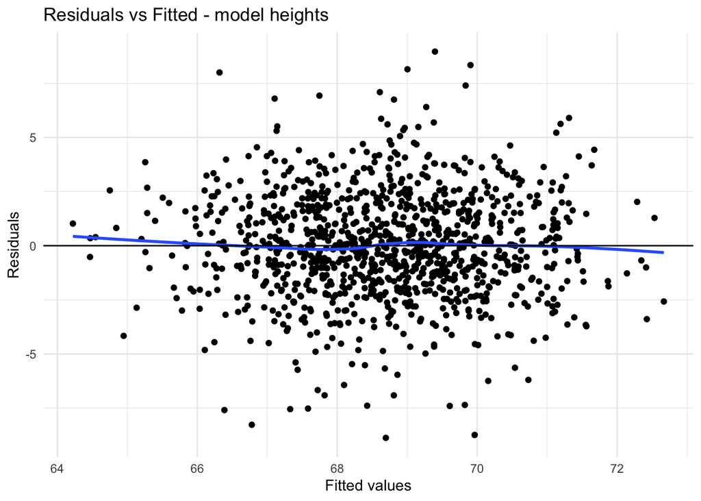

```r
residuals_heights <- residuals(model_heights_fs)
fitted_heights <- fitted(model_heights_fs)
res_fit_heights <- bind_cols(res = residuals_heights, fit = fitted_heights)

ggplot(data = res_fit_heights, aes(x = fit, y = res)) +
  geom_point()+
  geom_smooth(method = "loess", se = FALSE)+
  labs(x = "Fitted values", y = "Residuals", title = "Residuals vs Fitted - model heights") +
  geom_hline(yintercept = 0, color = "black")+
  theme_minimal()
```

As we see the line is around zero and the points seems to be normally distributed. We can assess the normal distribution of residuals by looking at the plot of the model which gives us 6 plots in total.

1. We check if the residuals are randomly (normally) distributed and lay along 0.
2. We check if the points lay along the straight line.
3. We check if the red line is horizontal across the plot (assumption of homoscedasticity is likely satisfied).
4. This shows the influence of each observation on the fitted values.

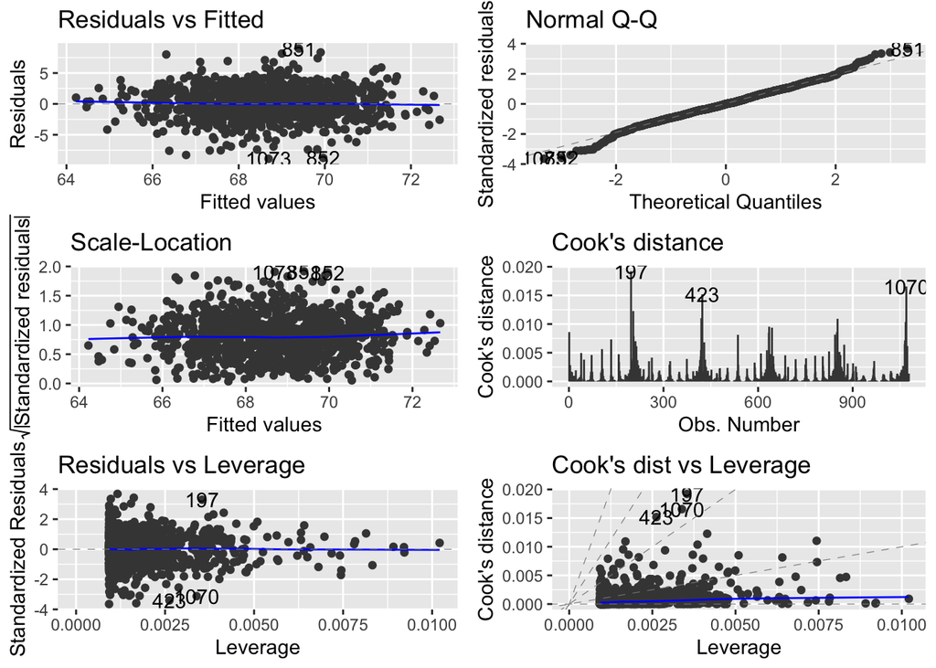

```r
autoplot(model_heights_fs, which = 1:6) # from ggplot2 and ggfortify
```

### Outliers, leverage and influence

**Outliers** can be on x or y axis. We can try to identify and plot both.

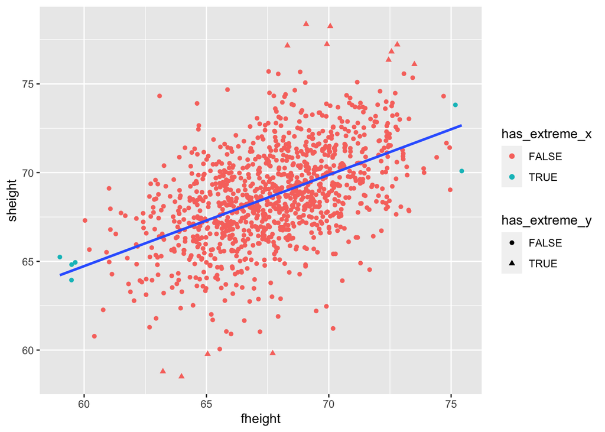

```r
heights_fs %>%
  mutate(has_extreme_x = fheight > 75 | fheight < 60) %>% # we need to define the threshold
  mutate(has_extreme_y = sheight > 76 | sheight < 60) %>% # we need to define the threshold
  ggplot(aes(x = fheight, y = sheight)) +
  geom_point(aes(color = has_extreme_x, shape = has_extreme_y)) +
  geom_smooth(method = "lm", se = FALSE)
```

**Leverage** tells us how extreme the explanatory variable values are (the most furthest away from x mean have the highest leverage).

```r
head(hatvalues(model_heights_fs)) # just first 6 values
```

```
##           1           2           3           4           5           6
## 0.001785637 0.003352885 0.001847313 0.001388879 0.006214606 0.003609046
```

```r
hatv <- augment(model_heights_fs) %>%
  pull(.hat)
hatv[1:6] # the same as above
```

```
## [1] 0.001785637 0.003352885 0.001847313 0.001388879 0.006214606 0.003609046
```

To identify values with high leverage:

```r
model_heights_fs %>%
  augment() %>%
  dplyr::select(sheight, fheight, leverage = .hat) %>% # there is also mass package loaded so I need to mask it with dplyr
  arrange(desc(leverage)) %>%
  head()
```

```
## # A tibble: 6 × 3
##   sheight fheight leverage
##     <dbl>   <dbl>    <dbl>
## 1    65.2    59.0  0.0102
## 2    63.9    59.5  0.00922
## 3    64.8    59.5  0.00921
## 4    64.9    59.6  0.00891
## 5    70.1    75.4  0.00832
## 6    67.3    60.0  0.00814
```

**Influence** measures how much the model would change if you left the observation out of the data when modeling. It is mostly measured with Cook’s distance. We could say that the most influential cases are the ones furthest away from the trend line.

```r
head(cooks.distance(model_heights_fs))
```

```
##            1            2            3            4            5            6
## 0.0086015882 0.0028918779 0.0024207643 0.0028130116 0.0005684765 0.0012789261
```

```r
model_heights_fs %>%
  augment() %>%
  dplyr::select(sheight, fheight, cooks_dist = .cooksd) %>% # there is also mass package loaded so I need to mask it with dplyr
  arrange(desc(cooks_dist)) %>%
  head()
```

```
## # A tibble: 6 × 3
##   sheight fheight cooks_dist
##     <dbl>   <dbl>      <dbl>
## 1    74.3    63.1     0.0192
## 2    58.8    63.2     0.0166
## 3    58.5    64.0     0.0152
## 4    77.2    72.8     0.0123
## 5    60.8    60.4     0.0110
## 6    61.2    70.2     0.0109
```

Once we identify some cases that are influential and extreme, we can leave them out of the analysis and re-create the model to obtain better results.

## Multiple linear regression

We can create a regression model with more than one explanatory variable. It can give us more insight and we can make better predictions.

### One numeric and one categorical explanatory variable

#### Parallel slopes

This is a model with two explanatory variables - one numeric and one categorical. Let’s remind ourselves models separately.

```r
model_kidsweights_numeric <- lm(weight ~ height, data = kid.weights) # model - numeric ~ numeric
model_kidsweights_numeric
```

```
##
## Call:
## lm(formula = weight ~ height, data = kid.weights)
##
## Coefficients:
## (Intercept)       height
##     -31.342        1.909
```

```r
model_kidsweights_cat <- lm(weight ~ gender + 0, data = kid.weights) # model - numeric ~ categorical
summary(model_kidsweights_cat)$coef
```

```
##         Estimate Std. Error  t value     Pr(>|t|)
## genderF 36.62016   2.182588 16.77832 9.802830e-43
## genderM 40.26446   2.253585 17.86685 1.880027e-46
```

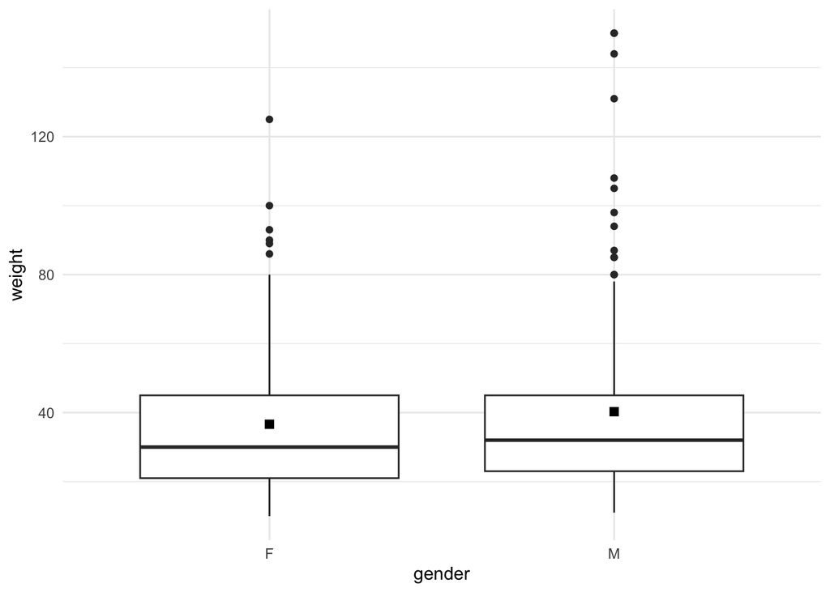

```r
ggplot(kid.weights, aes(x = gender, y = weight)) +
  geom_boxplot() +
  stat_summary(fun.y = mean, shape = 15) +
  theme_minimal() # we can expect non-significant difference between gender weights from this graph already
```

The one with numeric explanatory variable is pretty straight forward to understand.

The categorical one is a bit harder. If we want to include both categories of the variable and thus calculate response mean for both genders in this case, we need to add “+ 0” to the model (as we did). Or we could include just one called reference category which we can determine.

```r
model_kidsweights_cat_ref_M <- lm(weight ~ gender, data = kid.weights) # new model - this time with another reference
summary(model_kidsweights_cat_ref_M)$coef
```

```
##              Estimate Std. Error   t value     Pr(>|t|)
## (Intercept) 36.620155   2.182588 16.778321 9.802830e-43
## genderM      3.644308   3.137249  1.161625 2.465045e-01
```

```r
contrasts(kid.weights$gender)
```

```
##   M
## F 0
## M 1
```

```r
data_kidweights <- kid.weights %>%
  mutate(gender = relevel(gender, ref = "M")) # determination of the reference category
contrasts(data_kidweights$gender) # now is the reference category not female but male
```

```
##   F
## M 0
## F 1
```

```r
model_kidsweights_cat_ref_F <- lm(weight ~ gender, data = data_kidweights) # new model - this time with another reference
summary(model_kidsweights_cat_ref_F)$coef
```

```
##              Estimate Std. Error   t value     Pr(>|t|)
## (Intercept) 40.264463   2.253585 17.866853 1.880027e-46
## genderF     -3.644308   3.137249 -1.161625 2.465045e-01
```

Once we determine the reference category of the categorical explanatory variable, we can explain coefficients as follows:

1. model with a reference category F:
- incercept is the average weight of a kid being female, slope is a average difference in weight between males and females (if positive, males weigh more)
2. model with a reference category M: same but opposite idea

Alternatively, we could create a dummy variable -1/1 (M/F) and the results would be: b0 - b1 is male and b0 + b1 is female.

Now we can create a model with both the categorical and the numeric variable, so called **parallel slopes**.

```r
model_kidsweights_both <- lm(weight ~ height + gender + 0, data = kid.weights)
summary(model_kidsweights_both)$coef
```

```
##           Estimate Std. Error   t value     Pr(>|t|)
## height    1.905239 0.08353323 22.808155 9.993659e-63
## genderF -32.042290 3.25615843 -9.840519 1.716637e-19
## genderM -30.308104 3.34897318 -9.049969 4.388299e-17
```

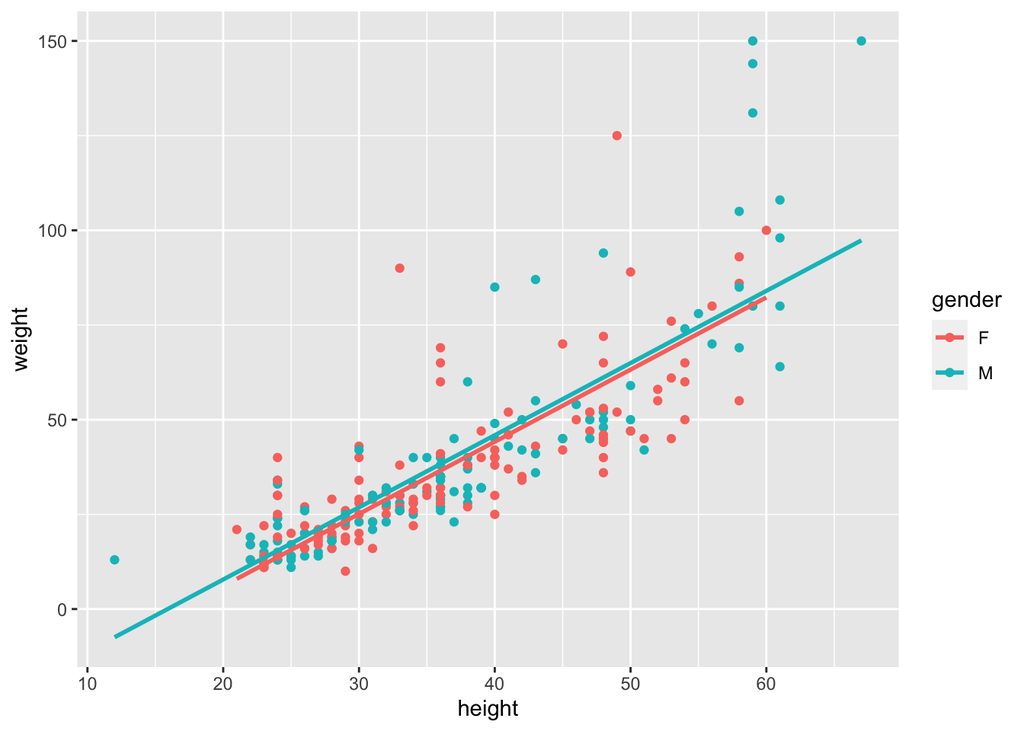

```r
plot_model_kidsweights_both <- ggplot(kid.weights, aes(x = height, y = weight, color = gender)) +
  geom_point() +
  geom_parallel_slopes(se = FALSE) # from package moderndive
plot_model_kidsweights_both
```

Let’s make some predictions.

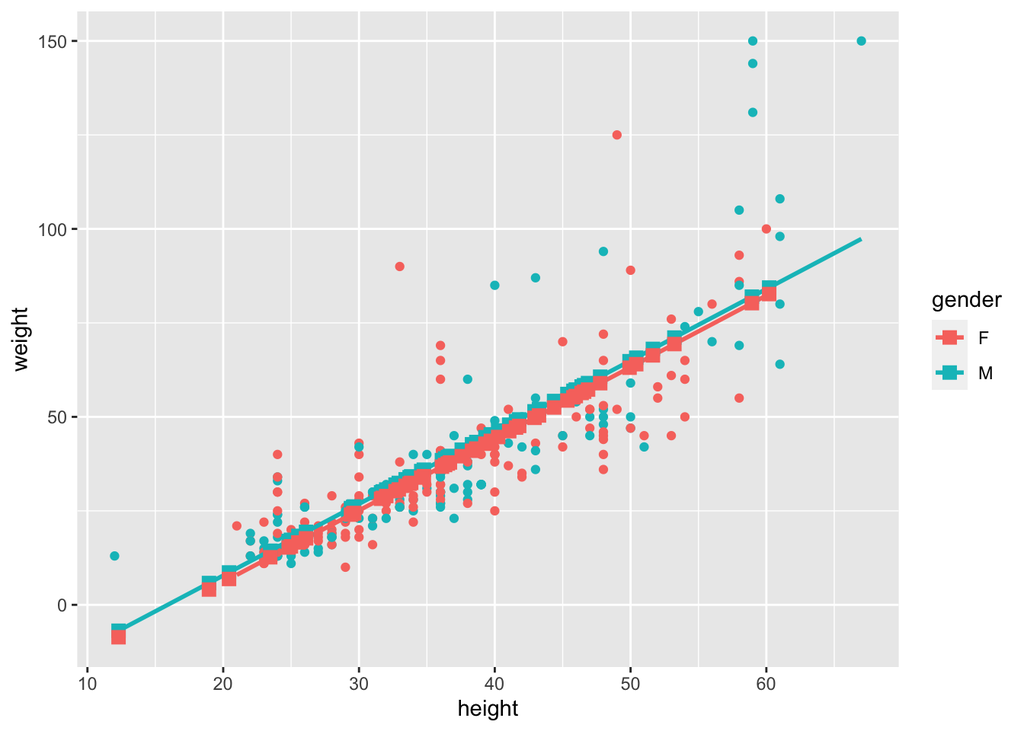

```r
new_kid.weights <- expand.grid( # to get each combination of all variables, we use expand.grid()
  height = rnorm(50, mean = 37, sd = 10.7), # descriptive values from summary
  gender = unique(kid.weights$gender)
)

prediction_data <- new_kid.weights %>%
  mutate(weight = predict(model_kidsweights_both, new_kid.weights))

plot_model_kidsweights_both +
  geom_point(data = prediction_data, size = 3, shape = 15)
```

**Assessing model performance**

It works basically the same way as for simple linear regression. We use a coefficient of determination (adjusted) or RSE.

```r
model_kidsweights_both %>%
  glance() %>%
  dplyr::select(1:3) # in case of multiple explanatory variables, it is necessary to use adjusted R squared to prevent overfitting (having a good model for this data but bad for other)
```

```
## # A tibble: 1 × 3
##   r.squared adj.r.squared sigma
##       <dbl>         <dbl> <dbl>
## 1     0.906         0.905  14.1
```

#### Interactions

We can often suppose that there is some connection between explanatory variables and that the effect of one explanatory variable on the expected response changes depending on the value of another exp. var.

```r
model_kidsweights_interaction <- lm(weight ~ height * gender, data = kid.weights) # either implicitly doing by multiplication
summary(model_kidsweights_interaction)
```

```
##
## Call:
## lm(formula = weight ~ height * gender, data = kid.weights)
##
## Residuals:
##     Min      1Q  Median      3Q     Max
## -28.466  -7.178  -2.978   2.979  67.506
##
## Coefficients:
##                Estimate Std. Error t value Pr(>|t|)
## (Intercept)    -21.4186     4.4831  -4.778 3.05e-06 ***
## height           1.6105     0.1197  13.450  < 2e-16 ***
## genderM        -18.4599     6.2382  -2.959 0.003386 **
## height:genderM   0.5532     0.1640   3.372 0.000865 ***
## ---
## Signif. codes:  0 '***' 0.001 '**' 0.01 '*' 0.05 '.' 0.1 ' ' 1
##
## Residual standard error: 13.81 on 246 degrees of freedom
## Multiple R-squared:  0.6939, Adjusted R-squared:  0.6902
## F-statistic: 185.9 on 3 and 246 DF,  p-value: < 2.2e-16
```

```r
model_kidsweights_interaction2 <- lm(weight ~ height + gender + height:gender, data = kid.weights) # or explicitly
# summary(model_kidsweights_interaction2) # this would print the same as above

# this way the output and coefficients are harder to understand, therefore we add + 0 to the formula
model_kidsweights_interaction_plus0 <- lm(weight ~  gender + gender:height + 0, data = kid.weights) # or explicitly
summary(model_kidsweights_interaction_plus0)
```

```
##
## Call:
## lm(formula = weight ~ gender + gender:height + 0, data = kid.weights)
##
## Residuals:
##     Min      1Q  Median      3Q     Max
## -28.466  -7.178  -2.978   2.979  67.506
##
## Coefficients:
##                Estimate Std. Error t value Pr(>|t|)
## genderF        -21.4186     4.4831  -4.778 3.05e-06 ***
## genderM        -39.8785     4.3378  -9.193  < 2e-16 ***
## genderF:height   1.6105     0.1197  13.450  < 2e-16 ***
## genderM:height   2.1636     0.1121  19.301  < 2e-16 ***
## ---
## Signif. codes:  0 '***' 0.001 '**' 0.01 '*' 0.05 '.' 0.1 ' ' 1
##
## Residual standard error: 13.81 on 246 degrees of freedom
## Multiple R-squared:  0.9101, Adjusted R-squared:  0.9086
## F-statistic: 622.5 on 4 and 246 DF,  p-value: < 2.2e-16
```

Interactions are like modelling for each category of categorical variable separately but this is more convenient.

##### Simpson’s paradox

It occurs when the trend (slope) of a model on the whole dataset is very different from the trends shown by models on subsets of the dataset.

```r
data_simpson <- simpsons_paradox[simpsons_paradox$dataset == "simpson_2",]
glimpse(data_simpson)
```

```
## Rows: 222
## Columns: 3
## $ dataset <chr> "simpson_2", "simpson_2", "simpson_2", "simpson_2", "simpson_2…
## $ x       <dbl> 62.24344, 52.33499, 56.36795, 66.80395, 66.53605, 62.38129, 38…
## $ y       <dbl> 70.608399, 14.705773, 46.395538, 66.174868, 89.246581, 91.4525…
```

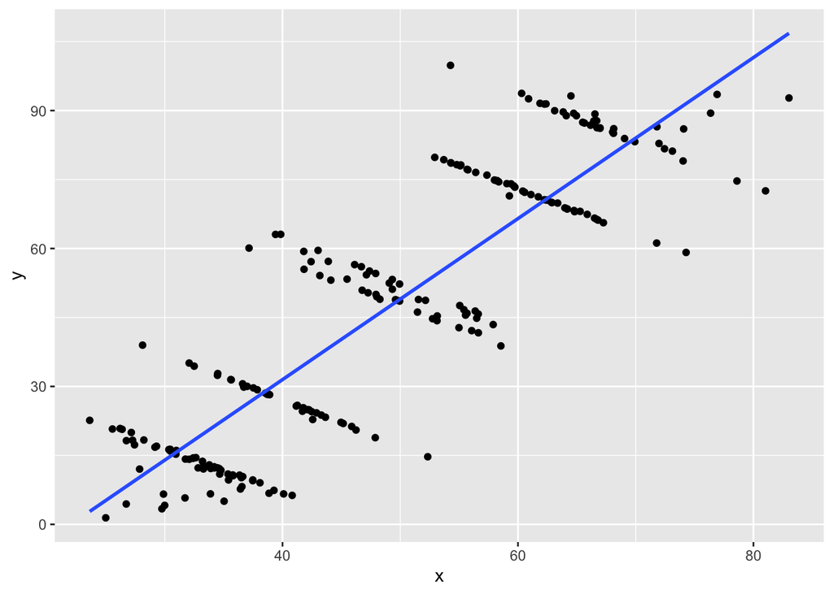

```r
ggplot(data_simpson, aes(x, y)) +
  geom_point() +
  geom_smooth(method = "lm", se = FALSE)
```

We see we are clearly missing some point here. Good advice is thus to plot the data every time during the initial analysis to find patterns which can completely change our ideas. Usually it is better to have more explanatory variables in the data that can give us more context and insight. It certainly depends on which question we want to answer. If the goal is the describe each subgroup of this data, then I would be reasonable to split it into 5 distinct subgroups and model each separately. If the question is if there is an overall change in y with x though then we don’t need to bother with splitting.

### Two numeric explanatory variables

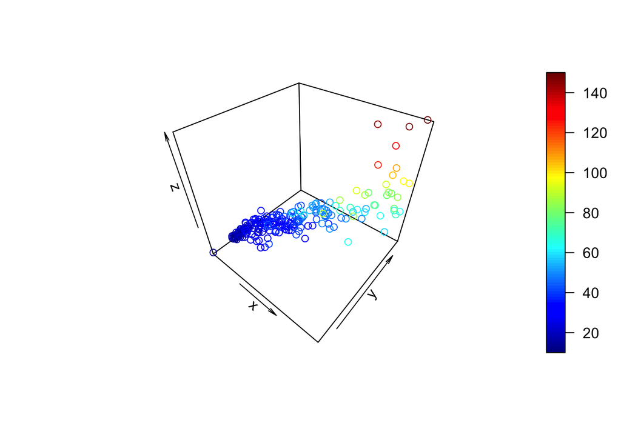

```r
scatter3D(kid.weights$age, kid.weights$height, kid.weights$weight) # hard to read
```

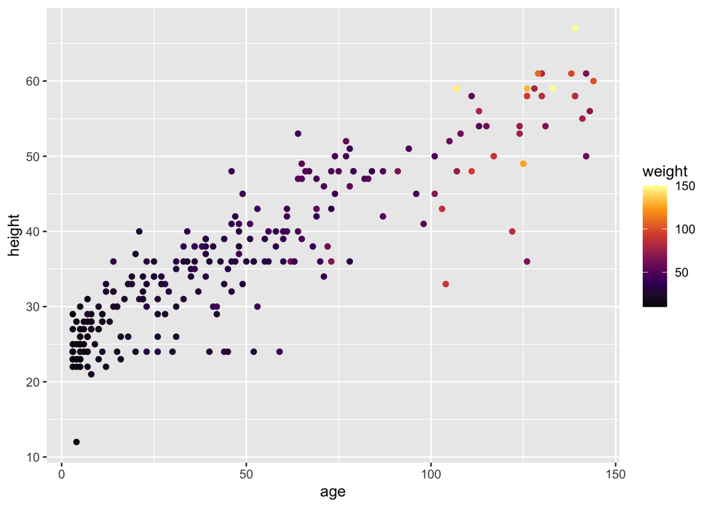

```r
ggplot(kid.weights, aes(age, height, color = weight))+
  geom_point()+
  scale_color_viridis_c(option = "inferno") # easier colors to distinguish, viridis_c for continuous data
```

Modeling and predictions are not much different. You just add another explanatory variable.

```r
model_kidsweights_twonumeric <- lm(weight ~ height + age, data = kid.weights)
summary(model_kidsweights_twonumeric)
```

```
##
## Call:
## lm(formula = weight ~ height + age, data = kid.weights)
##
## Residuals:
##     Min      1Q  Median      3Q     Max
## -27.241  -4.986  -0.394   3.495  69.865
##
## Coefficients:
##             Estimate Std. Error t value Pr(>|t|)
## (Intercept)  1.91816    4.03839   0.475  0.63522
## height       0.40698    0.15492   2.627  0.00915 **
## age          0.45052    0.04163  10.823  < 2e-16 ***
## ---
## Signif. codes:  0 '***' 0.001 '**' 0.01 '*' 0.05 '.' 0.1 ' ' 1
##
## Residual standard error: 11.63 on 247 degrees of freedom
## Multiple R-squared:  0.782,  Adjusted R-squared:  0.7802
## F-statistic: 442.9 on 2 and 247 DF,  p-value: < 2.2e-16
```

### More than two explanatory variables

If we want to include interactions, they can be 2-3 way.

```r
lm(GNP ~ Employed * Population * Unemployed, data = longley) # 3-way interactions
```

```
##
## Call:
## lm(formula = GNP ~ Employed * Population * Unemployed, data = longley)
##
## Coefficients:
##                    (Intercept)                        Employed
##                     -6.813e+03                       7.239e+01
##                     Population                      Unemployed
##                      7.079e+01                       7.571e+00
##            Employed:Population             Employed:Unemployed
##                     -7.570e-01                      -6.912e-02
##          Population:Unemployed  Employed:Population:Unemployed
##                     -1.007e-01                       1.134e-03
```

```r
lm(GNP ~ (Employed + Population + Unemployed) ^ 2, data = longley) # only 2-way interactions
```

```
##
## Call:
## lm(formula = GNP ~ (Employed + Population + Unemployed)^2, data = longley)
##
## Coefficients:
##           (Intercept)               Employed             Population
##            -3.850e+03              2.918e+01              4.315e+01
##            Unemployed    Employed:Population    Employed:Unemployed
##            -7.926e-01             -3.520e-01              4.756e-02
## Population:Unemployed
##            -2.040e-02
```

## Logistic regression

### Simple

It is one of generalized linear models and is used to model a binary/logical response variable.

```r
model_Melanoma <- glm(ulcer~time+status+sex+age+year+thickness, data = Melanoma, family = "binomial")
summary(model_Melanoma)
```

```
##
## Call:
## glm(formula = ulcer ~ time + status + sex + age + year + thickness,
##     family = "binomial", data = Melanoma)
##
## Deviance Residuals:
##     Min       1Q   Median       3Q      Max
## -3.3247  -0.7934  -0.6089   0.8992   1.9623
##
## Coefficients:
##               Estimate Std. Error z value Pr(>|z|)
## (Intercept)  7.380e+01  1.586e+02   0.465   0.6416
## time        -3.422e-04  2.022e-04  -1.693   0.0905 .
## status      -6.261e-01  3.360e-01  -1.863   0.0624 .
## sex          2.437e-01  3.432e-01   0.710   0.4776
## age          2.196e-03  1.044e-02   0.210   0.8334
## year        -3.728e-02  8.047e-02  -0.463   0.6431
## thickness    3.851e-01  8.798e-02   4.378  1.2e-05 ***
## ---
## Signif. codes:  0 '***' 0.001 '**' 0.01 '*' 0.05 '.' 0.1 ' ' 1
##
## (Dispersion parameter for binomial family taken to be 1)
##
##     Null deviance: 281.13  on 204  degrees of freedom
## Residual deviance: 223.18  on 198  degrees of freedom
## AIC: 237.18
##
## Number of Fisher Scoring iterations: 5
```

We can try to plot it but this time using glm smoothing method.

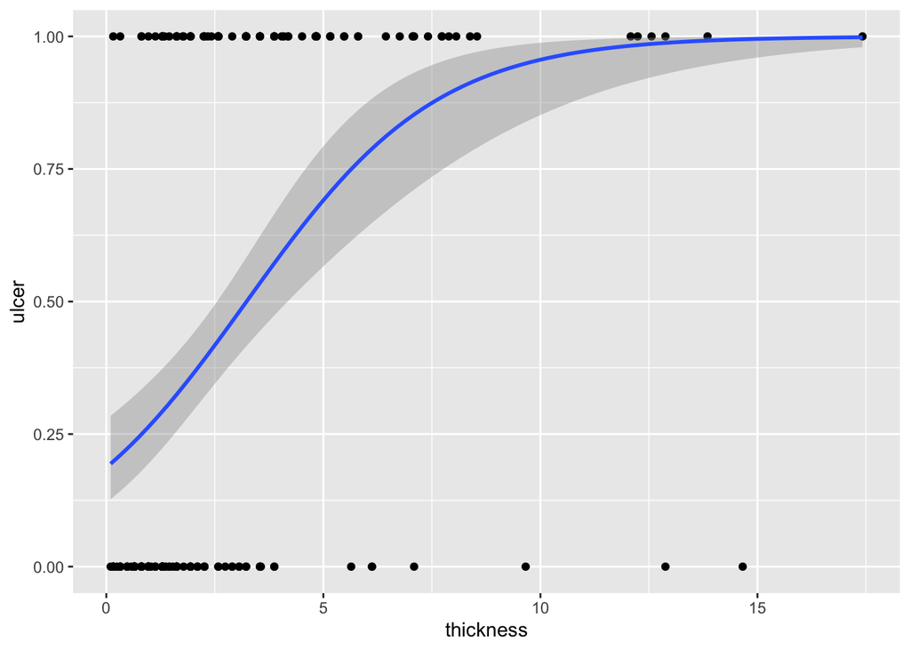

```r
model_Melanoma_2 <- glm(ulcer~thickness, data = Melanoma, family = "binomial") # only thickness is significant explanatory variable

intercept <- coefficients(model_Melanoma_2)[1]
slope <- coefficients(model_Melanoma_2)[7]
plot_Melanoma <- ggplot(Melanoma, aes(x = thickness, y = ulcer)) +
  geom_point() +
  geom_abline(intercept = intercept, slope = slope) +
  geom_smooth(method = "glm", method.args = list(family = binomial))
plot_Melanoma
```

And add some predictions.

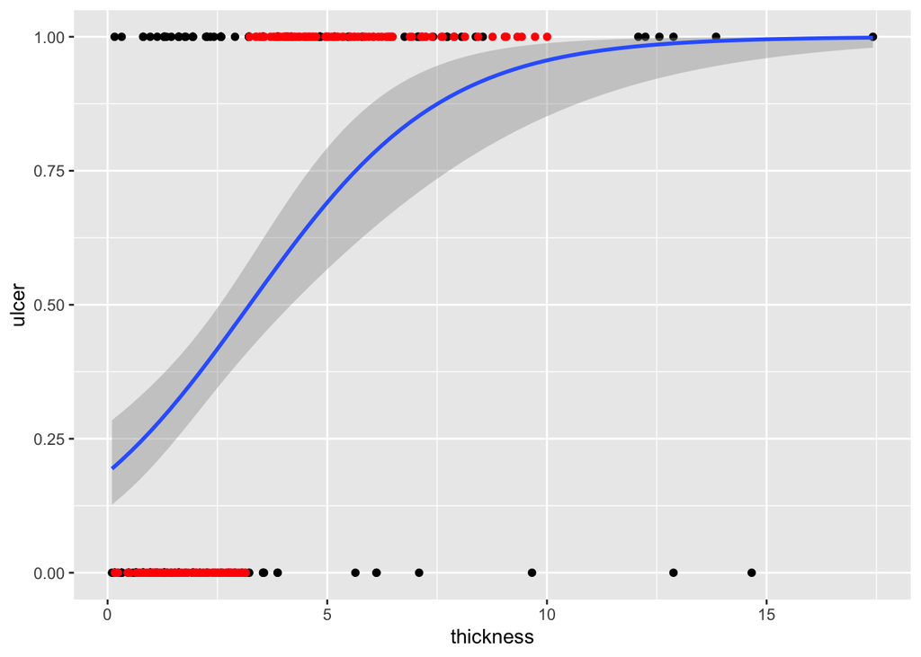

```r
set.seed(1)
new_thickness <- rnorm(200, 2.92, 2.95) # mean and sd found in descriptive statistics (summary)
new_thickness <- new_thickness[new_thickness > 0] # we need only positive values
new_Melanoma <- tibble(
  thickness = new_thickness
)
prediction_Melanoma <- new_Melanoma %>%
  mutate(ulcer = predict(model_Melanoma_2, new_Melanoma, type = "response")) %>%
  mutate(most_likely_outcome = round(ulcer)) %>%  # if ulcer is greater than 0.5 than it is likely to be true, and false otherwise
  mutate(odds_ratio = ulcer / (1-ulcer)) %>%
  mutate(log_odds_ratio = predict(model_Melanoma_2, new_Melanoma))

plot_Melanoma +
  geom_point(aes(y = most_likely_outcome), data = prediction_Melanoma, color = "red")
```

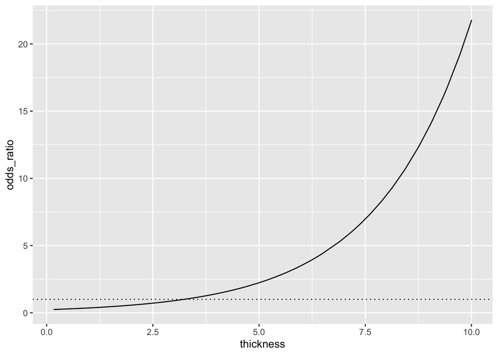

```r
ggplot(prediction_Melanoma, aes(x = thickness, y = odds_ratio)) +
  geom_line()+
  geom_hline(yintercept = 1, linetype = "dotted")
```

When **quatifying logistic regression fit**, instead of using regular statistics we use confusion matrix.

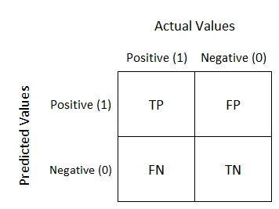

```r
actual_response <- Melanoma$ulcer
predicted_response <- round(fitted(model_Melanoma)) # we want the most likely outcome (0/1) for logistic regression
outcomes <- table(predicted_response, actual_response)
outcomes # this is the final confusion matrix ()
```

```
##                   actual_response
## predicted_response  0  1
##                  0 99 34
##                  1 16 56
```

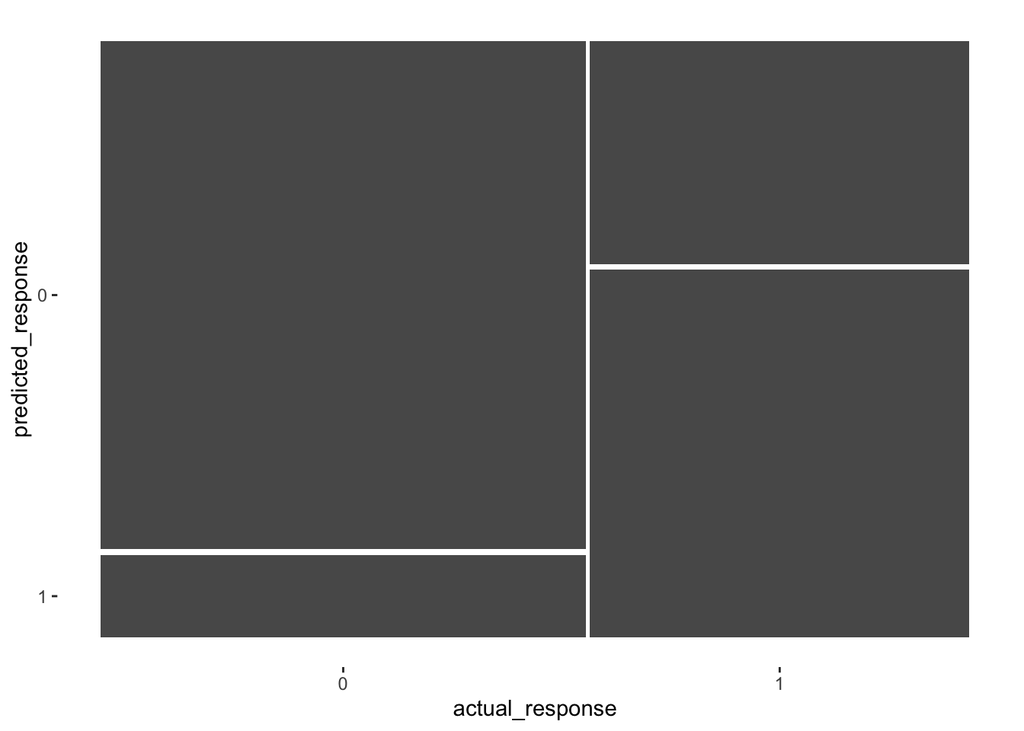

```r
confusion <- conf_mat(outcomes) # with yardstick package, we can convert table to an actual confusion matrix format and visualize it
autoplot(confusion) # the width of the columns is given by sum of actual values from conf mat
```

```r
summary(confusion, event_level = "second") # positive values are in the second level (0/1)
```

```
## # A tibble: 13 × 3
##    .metric              .estimator .estimate
##    <chr>                <chr>          <dbl>
##  1 accuracy             binary         0.756
##  2 kap                  binary         0.494
##  3 sens                 binary         0.622
##  4 spec                 binary         0.861
##  5 ppv                  binary         0.778
##  6 npv                  binary         0.744
##  7 mcc                  binary         0.502
##  8 j_index              binary         0.483
##  9 bal_accuracy         binary         0.742
## 10 detection_prevalence binary         0.351
## 11 precision            binary         0.778
## 12 recall               binary         0.622
## 13 f_meas               binary         0.691
```

Top 3 model performance metrics for logistic regression:

Accuracy is the proportion of correct predictions (TN + TP / all). The higher, the better. Sensitivity is the proportion of true positives (TP / FN + TP; predicted true when actually true). The higher, the better. Specificity is the proportion of true negatives (TN / TN + FP; predicted false when actually false). The higher, the better.

- There is a tradeoff between specificity and sensitivity (one is higher than second is lower).

### Multiple

Doing multiple logistic regression is the same as for the linear one. Just add another explanatory variable. Visualization is a bit different. With categorical variables included we need to use faceting to display model for every category. For two numeric exp variables, we use color for response variable (those below 0.5 one color and above another using `scale_color_gradient2(midpoint = 0.5)`).

For logistic regression, the optimization of fit is done rather with likelihood (better than sum of squares). The likelihood score is higher when the predicted value is closer to the actual one. When using likelihood metric, we end up having many very small numbers leading to numerical error. Therefore it is better to use log-likelihood which is also easier to compute. We went to maximize log-likelihood (minimize negative log-likelihood), which also maximizes the likelihood.